# Evidencia-2

```r
var_animales <- c(  "MT121215", "MT040333", "MG772933", "MN996532", "MG772934", "KJ473808","KJ473809","KJ473810", "KJ473811", "KJ473812", "KJ473813", "KJ473814", "KJ473815", "KJ473816","KJ473820","KJ473821", "KJ473822", "MT012098", "MT121216", "MT123291")
```

2.Obtén las secuencias:

```r
var_animales_sequences <- read.GenBank(var_animales)
```

3. Estructura del DNABin:

```r
str(var_animales_sequences)
```

```
## List of 20
##  $ MT121215: raw [1:29945] 88 18 18 88 ...
##  $ MT040333: raw [1:29805] 48 28 18 18 ...
##  $ MG772933: raw [1:29802] 88 18 88 18 ...
##  $ MN996532: raw [1:29855] 88 18 18 88 ...
##  $ MG772934: raw [1:29732] 88 18 88 18 ...
##  $ KJ473808: raw [1:26975] 88 88 48 18 ...
##  $ KJ473809: raw [1:27783] 18 18 18 18 ...
##  $ KJ473810: raw [1:27576] 48 18 18 48 ...
##  $ KJ473811: raw [1:29037] 48 48 18 18 ...
##  $ KJ473812: raw [1:29443] 88 48 48 18 ...
##  $ KJ473813: raw [1:29461] 48 48 18 18 ...
##  $ KJ473814: raw [1:29658] 18 28 18 28 ...
##  $ KJ473815: raw [1:29161] 48 18 28 28 ...
##  $ KJ473816: raw [1:29142] 48 18 18 18 ...
##  $ KJ473820: raw [1:30480] 48 88 18 18 ...
##  $ KJ473821: raw [1:30423] 48 88 18 18 ...
##  $ KJ473822: raw [1:30247] 18 18 18 18 ...
##  $ MT012098: raw [1:29854] 88 28 28 18 ...
##  $ MT121216: raw [1:29521] 28 88 28 48 ...
##  $ MT123291: raw [1:29882] 88 88 88 48 ...
##  - attr(*, "class")= chr "DNAbin"
##  - attr(*, "description")= chr [1:20] "MT121215.1 Severe acute respiratory syndrome coronavirus 2 isolate SARS-CoV-2/human/CHN/SH01/2020, complete genome" "MT040333.1 Pangolin coronavirus isolate PCoV_GX-P4L, complete genome" "MG772933.1 Bat SARS-like coronavirus isolate bat-SL-CoVZC45, complete …
##  - attr(*, "species")= chr [1:20] "Severe_acute_respiratory_syndrome_coronavirus_2" "Pangolin_coronavirus" "Bat_SARS-like_coronavirus" "Bat_coronavirus_RaTG13" ...
```

```r
attributes(var_animales_sequences)
```

```
## $names
##  [1] "MT121215" "MT040333" "MG772933" "MN996532" "MG772934" "KJ473808"
##  [7] "KJ473809" "KJ473810" "KJ473811" "KJ473812" "KJ473813" "KJ473814"
## [13] "KJ473815" "KJ473816" "KJ473820" "KJ473821" "KJ473822" "MT012098"
## [19] "MT121216" "MT123291"
##
## $class
## [1] "DNAbin"
##
## $description
##  [1] "MT121215.1 Severe acute respiratory syndrome coronavirus 2 isolate SARS-CoV-2/human/CHN/SH01/2020, complete genome"
##  [2] "MT040333.1 Pangolin coronavirus isolate PCoV_GX-P4L, complete genome"
##  [3] "MG772933.1 Bat SARS-like coronavirus isolate bat-SL-CoVZC45, complete genome"
##  [4] "MN996532.2 Bat coronavirus RaTG13, complete genome"
##  [5] "MG772934.1 Bat SARS-like coronavirus isolate bat-SL-CoVZXC21, complete genome"
```

[output cut: 37 more lines]

```r
names(var_animales_sequences)
```

```
##  [1] "MT121215" "MT040333" "MG772933" "MN996532" "MG772934" "KJ473808"
##  [7] "KJ473809" "KJ473810" "KJ473811" "KJ473812" "KJ473813" "KJ473814"
## [13] "KJ473815" "KJ473816" "KJ473820" "KJ473821" "KJ473822" "MT012098"
## [19] "MT121216" "MT123291"
```

```r
attr(var_animales_sequences, "species")
```

```
##  [1] "Severe_acute_respiratory_syndrome_coronavirus_2"
##  [2] "Pangolin_coronavirus"
##  [3] "Bat_SARS-like_coronavirus"
##  [4] "Bat_coronavirus_RaTG13"
##  [5] "Bat_SARS-like_coronavirus"
##  [6] "BtRf-AlphaCoV/YN2012"
##  [7] "BtNv-AlphaCoV/SC2013"
##  [8] "Alphacoronavirus_BtMs-AlphaCoV/GS2013"
##  [9] "BtRf-BetaCoV/JL2012"
## [10] "BtRf-BetaCoV/HeB2013"
## [11] "BtRf-BetaCoV/SX2013"
## [12] "BtRs-BetaCoV/HuB2013"
## [13] "BtRs-BetaCoV/GX2013"
## [14] "BtRs-BetaCoV/YN2013"
## [15] "BtPa-BetaCoV/GD2013"
## [16] "BtVs-BetaCoV/SC2013"
## [17] "BtTp-BetaCoV/GX2012"
## [18] "Severe_acute_respiratory_syndrome_coronavirus_2"
## [19] "Pangolin_coronavirus"
## [20] "Severe_acute_respiratory_syndrome_coronavirus_2"
```

4. Concentraremos en un archivo todas las secuencias:

```r
write.dna(var_animales_sequences,  file ="var_animales_seqs.fasta", format = "fasta", append =
FALSE, nbcol = 6, colsep = " ", colw = 10)
```

5. Cargamos la secuencias:

```r
var_animales_seq_not_align <- readDNAStringSet("var_animales_seqs.fasta", format = "fasta")
var_animales_seq_not_align
```

```
## DNAStringSet object of length 20:
##      width seq                                              names
##  [1] 29945 ATTAAAGGTTTATACCTTCCCAG...AAAAAAAAAAAAAAAAAAAAAA MT121215
##  [2] 29805 GCTTTAACTTTTTACAAATCCCA...CCCATGTGATTTTAATAGCTTC MT040333
##  [3] 29802 ATATTAGGTTTTTACCTTCCCAG...AAAAAAAAAAAAAAAAAAAAAA MG772933
##  [4] 29855 ATTAAAGGTTTATACCTTTCCAG...CTTCTTAGGAGAATGACAAAAA MN996532
##  [5] 29732 ATATTAGGTTTTTACCTTCCCAG...AAAAAAAAAAAAAAAAAAAAAA MG772934
##  ...   ... ...
## [16] 30423 GATTTAAGTGAATAGCCTAGCTA...AGATGATTAACAAAAAAAAAAA KJ473821
## [17] 30247 TTTTAACGAACTTAAATAATAGC...TAGATGATTAACAAAAAAAAAA KJ473822
## [18] 29854 ACCTTCCCAGGTAACAAACCAAC...AATAGCTTCTTAGGAGAATGAC MT012098
## [19] 29521 CACGCAGTATAATTAATAACTAA...AGAGCCACCACATTTTCACCGA MT121216
## [20] 29882 AAAGGTTTATACCTTCCCAGGTA...GAATGACAAAAAAAAAAAAAAA MT123291
```

6. Alineamiento de las secuencias:

```r
var_animales_seq_not_align <- OrientNucleotides(var_animales_seq_not_align)
```

```
## ========================================================================================================================================================================================================
##
## Time difference of 0.24 secs
```

```r
var_animales_seq_align <- AlignSeqs(var_animales_seq_not_align)
```

[output not shown]

7. Visualizar el resultado del alineamiento:

```r
BrowseSeqs(var_animales_seq_align, highlight=0)
```

8. Guardar el resultado:

```r
writeXStringSet(var_animales_seq_align, file="var_animales_seq_align.fasta")
```

9. Obtener el nuevo archivo:

```r
var_animales_aligned <- read.alignment("var_animales_seq_align.fasta", format = "fasta")
```

10. Crear una matriz de distancia:

```r
matriz_distancia <- dist.alignment(var_animales_aligned, matrix = "similarity")
```

11. Creación del árbol con el paquete ape:

```r
var_animales_tree <- nj(matriz_distancia)
class(var_animales_tree)
```

```
## [1] "phylo"
```

```r
var_animales_tree <- ladderize(var_animales_tree)
```

12. Plot del árbol:

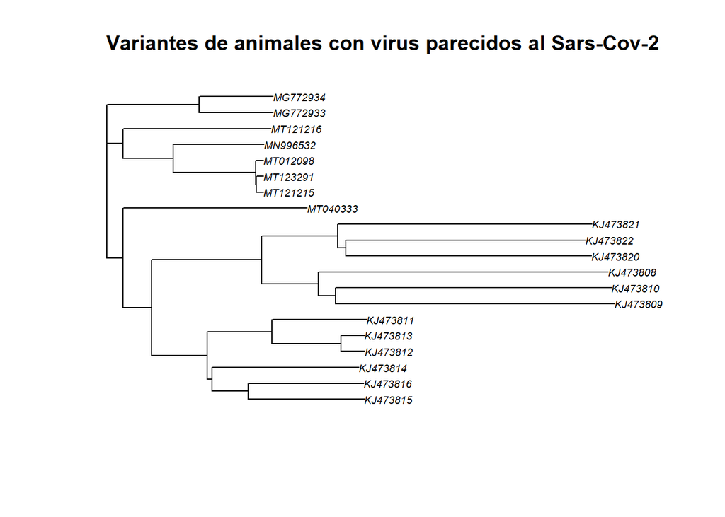

```r
plot(var_animales_tree, cex = 0.6)
title("Variantes de animales con virus parecidos al Sars-Cov-2")
```

INTERPRETACIÓN DEL ÁRBOL FILOGENÉTICO:

Los árboles filogenéticos representan la relación evolutiva que se ha dado entre distintos seres vivo a lo largo del tiempo, mientras que los genomas son la totalidad del material genético de un organismo [1,2]. Estos conceptos son la base para poder comprender la diversidad y evolución a lo largo del tiempo y de los distintos seres vivos que han habitado en nuestro planeta. Además, la secuenciación del genoma y la construcción de árboles filogenéticos son herramientas importantes para el estudio de las zoonosis, que son las enfermedades infecciosas que se transmiten de los animales a los humanos [3].